# Exam 1

## Exam 1

#### Question

1. El líder de un programa de adopción de mascotas encuestó a 150 personas para conocer qué animal les interesaría adoptar. Del total de encuestados, el 45% adoptaría un erizo, el 35% adoptaría un pez y el 20% adoptaría una cabra.

   ¿Cuál de las siguientes representaciones NO muestra correctamente la información recolectada en la encuesta?

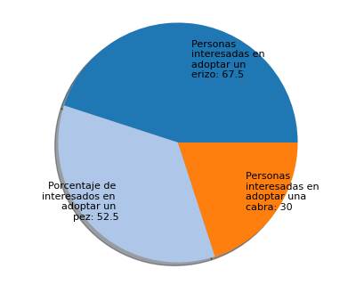

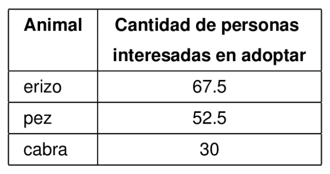

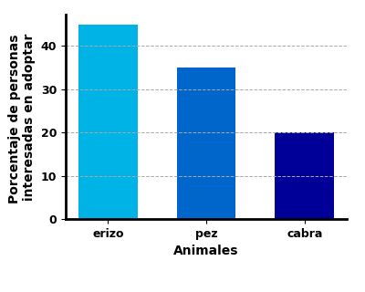

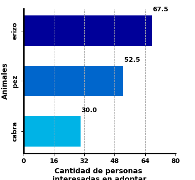

#### Solution

   La representación que **NO muestra correctamente** la información recolectada en la encuesta es el **gráfico de torta**.

   **Análisis de las representaciones:**
   - **Tabla**: **Correcta**. Muestra números absolutos de personas que corresponden correctamente a los porcentajes mencionados en la encuesta.
   - **Gráfico de barras verticales**: **Correcto**. Muestra porcentajes de personas interesadas en adoptar cada animal, correspondiendo correctamente con la información de la encuesta.
   - **Gráfico de barras horizontales**: **Correcto**. Muestra números absolutos de personas que corresponden correctamente a los porcentajes de la encuesta.
   - **Gráfico de torta**: **Incorrecto**. Las etiquetas son inconsistentes: mientras dos segmentos dicen “Personas interesadas en adoptar”, el segundo segmento dice “Porcentaje de interesados en adoptar”. Esta inconsistencia en la terminología hace que la representación sea confusa e incorrecta.

   **Por lo tanto, el gráfico de torta es el único que NO muestra correctamente la información debido a sus etiquetas inconsistentes, mientras que las demás opciones SÍ la representan correctamente.**

   **La gráfica incorrecta es:**

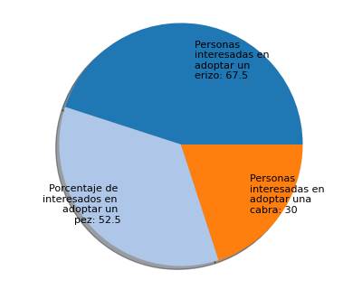